```python
import numpy as np
import cv2 as cv
from matplotlib import pyplot as plt

def disImg(img,BGR2RGB=True):
    if BGR2RGB:
        plt.imshow(cv.cvtColor(img,cv.COLOR_BGR2RGB))
    else:
        plt.imshow(img)
    plt.xticks([]), plt.yticks([])  # 隐藏 x 轴和 y 轴上的刻度值
    plt.show()

def disImg(*img,BGR2RGB=True):
    imgNum=len(img)
    colEx=100+imgNum*10+1
    plt.figure(figsize=(10,10))
    for i in range(imgNum):
        if BGR2RGB:
            plt.subplot(colEx+i),plt.imshow(cv.cvtColor(img[i],cv.COLOR_BGR2RGB))
        else:
            plt.subplot(colEx+i),plt.imshow(img[i])
        plt.xticks([]), plt.yticks([])  # 隐藏 x 轴和 y 轴上的刻度值
    plt.show()

img1 = cv.imread('volleyball.jpg')
img2 = cv.imread('opencv-logo.jpg')
```

# 图像处理

## 几何变换

### 缩放

cv2.resize(InputArray src, Size, fx, fy, interpolation)

| 参数 | 描述 |
| --- | --- |
| InputArray src | 输入图片 |
| Size | 输出图片尺寸 |
| fx, fy | 沿x轴，y轴的缩放系数 |
| interpolation | 插入方式 |

| 插值方法 | 描述 |
| --- | --- |
| INTER_NEAREST | 最近邻插值 |
| INTER_LINEAR | 双线性插值（默认设置） |
| INTER_AREA | 使用像素区域关系进行重采样。 |
| INTER_CUBIC | 4x4像素邻域的双三次插值 |
| INTER_LANCZOS4 | 8x8像素邻域的Lanczos插值 |

```python
img3=cv.resize(img2,None,fx=0.2, fy=0.2, interpolation = cv.INTER_CUBIC)
img4=cv.resize(img2,(100,100), interpolation = cv.INTER_CUBIC)
print('src:',img2.shape)
print('img3:',img3.shape)
print('img4:',img4.shape)
```

```
src: (250, 274, 3)
img3: (50, 55, 3)
img4: (100, 100, 3)
```

### 平移

平移是物体位置的移动。

**img1=cv.warpAffine(img,M,(cols,rows))**图像的矩阵运算

- **img1**：输出的图片
- **img**：输入图片
- **M**：平移矩阵
- **(cols,rows)**：输出图像大小

若已知图像在(x,y)方向上的位移，则将其设为(tx,ty)，你可以创建转换矩阵**M**，如下所示：

$M=\left[ \begin{matrix} 1 &0 &t_x\\0 &1 &t_y \end{matrix} \right]$

将上述矩阵放入**np.float32**类型的Numpy数组中，并将其传递给**cv.warpAffine**函数。参见下面偏移为(100, 50)的示例：

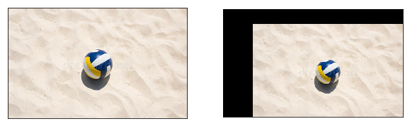

```python
M = np.float32([[1,0,100],[0,1,50]])#平移矩阵
dst = cv.warpAffine(img1,M,(img1.shape[1]+100,img1.shape[0]+50))
disImg(img1,dst)
```

### 旋转

1.使用**cv.getRotationMatrix2D**获取旋转矩阵 2.使用**cv.warpAffine**进行矩阵运算

**cv.getRotationMatrix2D(center,angle,scale)**

| 参数 | 描述 |
| --- | --- |
| center | 旋转的中心点 |
| angle | 旋转的角度，正值是逆时针，负值为顺时针 |
| scale | 缩放因子 |

[figure not shown]

```python
rows,cols,c = img1.shape
# cols-1 和 rows-1 是坐标限制
M = cv.getRotationMatrix2D(((cols-1)/2.0,(rows-1)/2.0),60,0.5)
dst=cv.warpAffine(img1,M,(img1.shape[1],img1.shape[0]))
disImg(img1,dst)
```

### 仿射变换

仿射变换可以看成是被测面在空间翻滚后在某个基准面上的投影。在仿射变换中，原始图像中的所有平行线在输出图像中仍将平行。

[figure not shown]

为了找到变换矩阵，我们需要输入图像中的三个点及这三个点在输出图像中的对应位置。然后使用**cv.getAffineTransform**创建一个2x3矩阵，并把该矩阵将传递给**cv.warpAffine**。

[figure not shown]

[figure not shown]

```python
pts1 = np.float32([[50,50],[200,50],[50,200]])
pts2 = np.float32([[100,200],[300,150],[200,350]])
M = cv.getAffineTransform(pts1,pts2)
dst=cv.warpAffine(img1,M,(img1.shape[1]*2,img1.shape[0]*2))
disImg(img1,dst)
```

### 透视变换

透视变换可以看成是被测面在空间中翻滚后从观察者角度发生的变化。在透视变换后直线仍将保持直线

[figure not shown]

为了找到变换矩阵，我们需要输入图像中的四个点及这四个点在输出图像中的对应位置。然后使用**cv.getPerspectiveTransform**创建一个3x3矩阵，并把该矩阵将传递给**cv.warpPerspective**。

[figure not shown]

```python
pts1 = np.float32([[100,50],[100,390],[500,50],[500,390]])
pts2 = np.float32([[200,100],[200,330],[500,50],[500,390]])
M = cv.getPerspectiveTransform(pts1,pts2)
dst=cv.warpPerspective(img1,M,(img1.shape[1],img1.shape[0]))
disImg(img1,dst)
```

## 图像平滑

### 卷积

卷积可以理解为一种图像滤波的方法，实质是两个矩阵（图片与卷积核）之间的一种运算，卷积核的大小通常是3x3、5x5、7x7等

[figure not shown]

卷积可用于在图像中提取特征，在大名鼎鼎的CNN网络中，图像的特征就是由一系列卷积操作组成的网络提取出来的

我们可以通过构造合适的卷积核，使卷积操作后的图像变得平滑，例如：

$K=\frac{1}{25}\left[ \begin{matrix} 1 &1 &1&1&1\\1 &1 &1&1&1\\1 &1 &1&1&1\\1 &1 &1&1&1\\1 &1 &1&1&1 \end{matrix} \right]$ 就可以实现5x5的平均滤波的效果

OpenCV中使用**cv.filter2D**函数进行卷积运算

**dst=cv.filter2D(src, ddepth, kernel[, dst[, anchor[, delta[, borderType]]]])**

| 参数 | 描述 |
| --- | --- |
| src | 原图像 |
| dst | 目标图像，与原图像尺寸和通过数相同 |
| ddepth | 目标图像的所需深度（数据类型） |
| kernel | 卷积核（或相当于相关核），单通道浮点矩阵;如果要将不同的内核应用于不同的通道，请使用拆分将图像拆分为单独的颜色平面，然后单独处理它们。 |
| anchor | 内核的锚点，指示内核中过滤点的相对位置;锚应位于内核中;默认值（-1，-1）表示锚位于内核中心。 |
| detal | 在将它们存储在dst中之前，将可选值添加到已过滤的像素中。类似于偏置。 |
| borderType | 像素外推法，参见BorderTypes |

| Input depth (src.depth()) | Output depth (ddepth) |
| --- | --- |
| CV_8U | -1/CV_16S/CV_32F/CV_64F |
| CV_16U/CV_16S | -1/CV_32F/CV_64F |
| CV_32F | -1/CV_32F/CV_64F |
| CV_64F | -1/CV_64F |

**Note**：当ddepth=-1时，表示输出图像与原图像有相同的深度。

[figure not shown]

```python
kernel = np.ones((5,5),np.float32)/25
dst = cv.filter2D(img2,-1,kernel)
disImg(img2,dst)
```

### 平均滤波

**cv.blur**对滤波核范围内的像素进行算数平均，计算出新的像素值

[figure not shown]

```python
dst = cv.blur(img2,(9,9))
disImg(img2,dst)
```

### 中值滤波

函数**cv.medianBlur()** 提取内核区域下所有像素的中值，并将中心元素替换为该中值。这对于消除图像中的椒盐噪声非常有效。

[figure not shown]

```python
dst = cv.medianBlur(img2,9)
disImg(img2,dst)
```

### 高斯滤波

**cv.GaussianBlur**滤波核范围内的像素进行高斯平均，计算出新的像素值,高斯模糊对于从图像中去除高斯噪声非常有效

高斯平均就是在滤波核的范围内的每个像素叠加一个以滤波核中心位置为$\mu$的呈二维高斯分布权重，滤波核范围内每个像素乘以这个权重后再算出平均值

- GaussianBlur(src, ksize, sigmaX, dst=None, sigmaY=None, borderType=None)
  - **src**: 原图像
  - **dst**: 目标图像
  - **ksize**: 高斯核的大小；(width, height)；两者都是正奇数；如果设为0，则可以根据sigma得到；
  - **sigmaX**: X方向的高斯核标准差；
  - sigmaY: Y方向的高斯核标准差； 如果sigmaY设为0，则与sigmaX相等； 如果两者都为0，则可以根据ksize来计算得到；
  - borderType: 添加边框的模式

[figure not shown]

```python
dst = cv.GaussianBlur(img2,(9,9),0)
disImg(img2,dst)
```

### 双边滤波

高斯滤波的空间核是基于空间计算的，也就是窗口内每个像素的权值只与其相对窗口中心点的位置有关，在这个基础上，再增加一个基于颜色(亮度)计算的高斯核，就是双边滤波。双边滤波可以在过滤噪点的时候保留真正的边缘。

- cv2.bilateralFilter(src, d, sigmaColor, sigmaSpace[, dst[, borderType]])
  - **src**：输入图像
  - **d**：过滤时周围每个像素领域的直径
  - **sigmaColor**：在color space中过滤sigma。参数越大，临近像素将会在越远的地方mix。
  - **sigmaSpace**：在coordinate space中过滤sigma。参数越大，那些颜色足够相近的的颜色的影响越大。

[figure not shown]

```python
dst = cv.bilateralFilter(img2,9,75,75)
disImg(img2,dst)
```

## 形态学变换

### 腐蚀

这里的腐蚀可以把图像上有颜色的地方看成前景，黑色看成背景，腐蚀就是背景侵蚀前景的操作，原始图像中的一个像素(无论是1还是0)只有当内核下的所有像素都是1时才被认为是1

- **cv.erode(src,kernel,iterations)**
  - src：原图
  - kernel：核，或者理解为窗口
  - iterations：递归次数

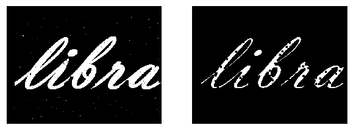

```python
img3=cv.imread("Morphology.png",cv.IMREAD_GRAYSCALE)
kernel = np.ones((7,7),np.uint8)
dst = cv.erode(img3,kernel,iterations = 1)
disImg(img3,dst)
```

### 膨胀

与腐蚀相反

- **cv.dilate(img,kernel,iterations)**

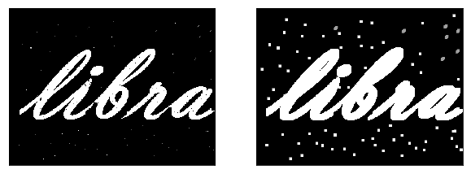

```python
kernel = np.ones((7,7),np.uint8)
dst = cv.dilate(img3,kernel,iterations = 1)
disImg(img3,dst)
```

### 开运算

**腐蚀然后膨胀**。它可以将原先连接并不紧密的前景断开，它对于消除噪音也很有用。在这里，我们使用形态学运算函数**cv.morphologyEx()**

- **cv.morphologyEx(src, op, kernel)**
  - src：原图
  - kernel：核，或者理解为窗口
  - op：进行的形态学操作

| 参数 | 描述 |
| --- | --- |
| cv.MORPH_OPEN | 开运算 |
| cv.MORPH_CLOSE | 闭运算 |
| cv.MORPH_GRADIENT | 形态学梯度 |
| cv.MORPH_TOPHAT | 礼帽 |
| cv.MORPH_BLACKHAT | 黑帽 |

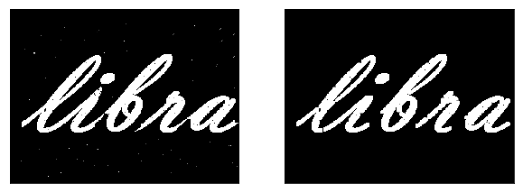

```python
kernel = np.ones((7,7),np.uint8)
dst = cv.morphologyEx(img3,cv.MORPH_OPEN,kernel)
disImg(img3,dst)
```

### 闭运算

**膨胀然后腐蚀**。它可以使原先离得不太远的前景连起来，它也可以消除前景中的小孔。

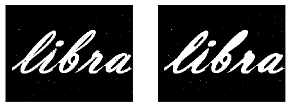

```python
kernel = np.ones((7,7),np.uint8)
dst = cv.morphologyEx(img3,cv.MORPH_CLOSE,kernel)
disImg(img3,dst)
```

### 形态学梯度

扩张减去腐蚀，获得原图中梯度最大的部分，类似于轮廓

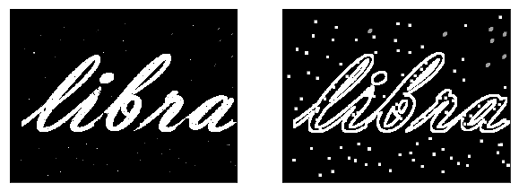

```python
kernel = np.ones((7,7),np.uint8)
dst = cv.morphologyEx(img3,cv.MORPH_GRADIENT,kernel)
disImg(img3,dst)
```

### 礼帽

输入图减去开运算，可以理解为原图像前景之间连接的部分

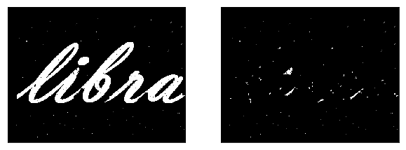

```python
kernel = np.ones((7,7),np.uint8)
dst = cv.morphologyEx(img3,cv.MORPH_TOPHAT,kernel)
disImg(img3,dst)
```

### 黑帽

闭运算减去输入图，可以理解为原图像前景上的小孔

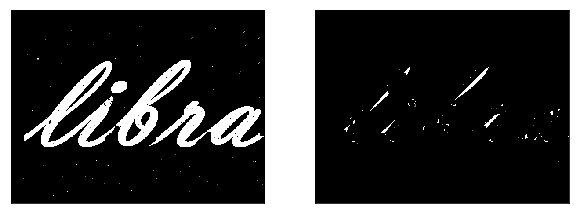

```python
kernel = np.ones((7,7),np.uint8)
dst = cv.morphologyEx(img3,cv.MORPH_BLACKHAT,kernel)
disImg(img3,dst)
```

## 图像阈值

定义：图像的二值化，就是将图像上的像素点的灰度值设置为0或255，也就是将整个图像呈现出明显的只有黑和白的视觉效果

### 简单阈值

人工设定阈值并与每个像素进行对比

- ret, dst = cv2.threshold(src, thresh, maxval, type)
  - src 原图像，原图像应该是灰度图
  - thresh 阈值
  - maxval 指当像素值高于（有时是小于）阈值时应该被赋予的新的像素值
  - type 可选以下5种方法

| 参数 | 描述 |
| --- | --- |
| cv2.THRESH_BINARY | 大于阈值的部分像素值变为最大值，其他变为0 |
| cv2.THRESH_BINARY_INV | 大于阈值的部分变为0，其他部分变为最大值 |
| cv2.THRESH_TRUNC | 大于阈值的部分变为阈值，其余部分不变 |
| cv2.THRESH_TOZERO | 大于阈值的部分不变，其余部分变为0 |
| cv2.THRESH_TOZERO_INV | 大于阈值的部分变为0，其余部分不变 |

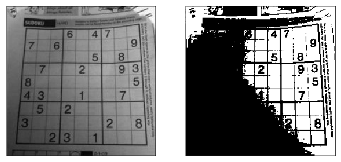

```
127.0
```

```python
img4=cv.imread("gradients.jpg",cv.IMREAD_GRAYSCALE)
ret,dst=cv.threshold(img4,127,255,cv.THRESH_BINARY)
disImg(img4,dst)
ret
```

### 自适应阈值

自适应阈值二值化函数根据图片一小块区域的值来计算对应区域的阈值，从而得到也许更为合适的图片。

- dst = cv2.adaptiveThreshold(src, maxval, thresh_type, type, Block Size, C)
  - src： 输入图，只能输入单通道图像，通常来说为灰度图
  - dst： 输出图
  - maxval： 当像素值超过了阈值（或者小于阈值，根据type来决定），所赋予的值
  - thresh_type： 阈值的计算方法，包含以下2种类型：直接平均值cv2.ADAPTIVE_THRESH_MEAN_C； 根据高斯分布计算权值cv2.ADAPTIVE_THRESH_GAUSSIAN_C
  - type：二值化操作的类型，与固定阈值函数相同
  - Block Size： 图片中分块的大小
  - C ：阈值计算方法中的常数项

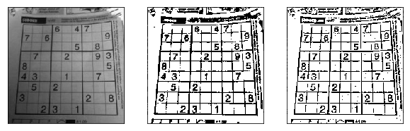

```python
dst1=cv.adaptiveThreshold(img4,255,cv.ADAPTIVE_THRESH_MEAN_C,\
                          cv.THRESH_BINARY,21,5)
dst2=cv.adaptiveThreshold(img4,255,cv.ADAPTIVE_THRESH_GAUSSIAN_C,\
                          cv.THRESH_BINARY,11,5)
disImg(img4,dst1,dst2)
```